# Data challenge prédiction de l’histologie

Lucas Chabeau

01/12/2019

# 1. Présentation du problème et prétraitement des données.

### Problématique

Nous possédons un jeu de données sur plusieurs centaines de patients atteints de deux pathologique qui s’opposent :

- **Le carcinome épidermoïde de poumons** : cancer qui se développe sur de la peau et des muqueuses (si j’ai bien compris).
- **L’adenocarcinome de poumons** : tumeur maligne qui se développe sur des glandes.

*Documentation lue pour comprendre la différence entre les deux pathologies*

- https://cancer.ooreka.fr/astuce/voir/447863/adenocarcinome
- https://fr.wikipedia.org/wiki/Carcinome_%C3%A9pidermo%C3%AFde
- https://fr.wikipedia.org/wiki/Ad%C3%A9nocarcinome
- https://fr.esdifferent.com/difference-between-carcinoma-and-adenocarcinoma

La problématique de ce datachallenge est de trouver un modèle de régréssion logistique qui prédit au mieux l’histologie des patients (carcinome épidermoïde ou adenocarcinome) avec un peu plus de 1000 variables explicatives à nore disposition.

### Traitement préliminaire des données

Tranformation des variables qualitatives en variables de type “factor”.

```r
#Jeu de données d'apprentissage
for ( v in c("sex", "tissue_status", "histology", "os_months", "dead", "dead_at_24_months", "t", "n", "m", "tnm_stage", "tnm_grade") ) {
    d[[ v ]] <- as.factor(x = d[[ v ]])
}

#Jeu de données de test
for ( v in c("sex", "tissue_status", "histology", "os_months", "dead", "dead_at_24_months", "t", "n", "m", "tnm_stage", "tnm_grade") ) {
    test[[ v ]] <- as.factor(x = test[[ v ]])
}
```

Le caractère “-” présent dans certaines variables posera problème lors de l’écriture d’expression des modèles ( “-” est un caractère pris en compte dans l’expression du modèle, comme “+”). Nous anticipons donc cette erreur ici..

```r
#Renommage des variables avec des caractères qui posent problème (-)
names(d) <- sub("-","_",names(d))
names(test) <- sub("-","_",names(d))
```

# 2. Séléction du modèle.

Nous commençons par vérifier que notre échantillon contient des effectifs suffisants de chaque classe pour construire notre modèle. Nous voyons que c’est bon.

```
##
## TCGA-LUAD TCGA-LUSC
##       273       273
```

Nous commençons la séléction du modèle en regardant les caractéristiques de tous les modèles univariés de l’histologie expliquée par les gènes. Le volcano plot ci-dessous montre en abscisse la valeur des $\beta$ estimés dans le modèle univarié et en ordonnée le log10 de la p-valeur du modèle.

```r
#Variables gênes
genes <- names(d[,13:1012])

#Fonction qui calcule
Genes_univ <- function(g){
  modele = glm(as.factor(c(as.vector(d$histology), rep("TCGA-LUAD", 2), rep("TCGA-LUSC", 2)))~c(d[[g]],0,max(d[,genes]),0,max(d[,genes])), family = binomial(link = 'logit'))
  b = modele$coefficients[[2]]
  pv = summary(modele)$coefficients[2,4]
  return(c(pval = pv,beta = b))
}

#Enregistrement des betas et des p-valeurs dans une dataframe
res <- sapply(genes, Genes_univ)
res <- as.data.frame(t(res))
```

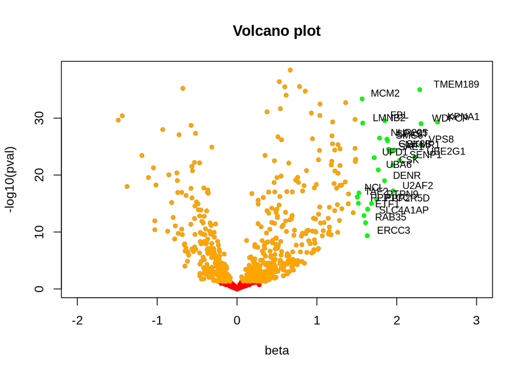

```r
#Base du graphique
with(res, plot(beta, -log10(pval), pch=20, main="Volcano plot", xlim=c(-2,3)))

#Ajout des couleurs
with(subset(res, pval>0.05 & abs(beta)<1.5 ), points(beta, -log10(pval), pch=20, col="red"))
with(subset(res, (pval<0.05 & abs(beta)<1.5)  | (pval>0.05 & abs(beta)>1.5) ), points(beta, -log10(pval), pch=20, col="orange"))
with(subset(res, pval<0.05 & abs(beta)>1.5), points(beta, -log10(pval), pch=20, col="green"))

#Ajout des noms des meilleurs gènes
library(calibrate)
with(subset(res, pval<0.05 & abs(beta)>1.5), textxy(beta, -log10(pval), rownames(subset(res, pval<0.05 & abs(beta)>1.5)), cex=.8))
```

- En vert, nous avons les gènes dont le modèle univarié avait une p-valeur inférieure à 0.05 et un $\beta$ plus grand que 1.5 ou plus petit que -1.5 (valeur arbitraire qui peut être redéfinie tant que |$\beta$| est suffisammet grand, je l’ai choisie car elle permet d’avoir un nombre raisonnable de gènes).
- En orange, les gènes pour lesquels nous une des deux conditions est remplie (p-valeur ou $\beta$).
- En rouge, les autres gènes.

Nous allons donc prendre les gènes en vert et faire notre séléction de variable avec un processus “stepwise” qui partira de cette base.

```r
#Formule du modèle de départ
formul <- paste("d$histology ~", paste(rownames(subset(res, pval<0.05 & abs(beta)>1.5)), collapse = " + "), " ")

#Création du modèle de départ
model <- glm(
    formula = formul,
    data = d,
    family = binomial(link = 'logit')
)

#Sélection de variables par méthode stepwise
step(model, dir='both')
```

```
## Start:  AIC=140.62
## d$histology ~ TAF2 + UBE2G1 + SLC4A1AP + UBA6 + PPP1CC + NUP205 +
##     ERCC3 + GSK3B + KPNA1 + ETF1 + CSK + PPP2R5D + VPS8 + SENP1 +
##     TMEM189 + WDPCP + SMC6 + UFD1 + LMNB2 + FBL + MTMR1 + RAB35 +
##     SAE1 + U2AF2 + DENR + PTPN9 + NCL + MCM2 + SPAST
##
##            Df Deviance    AIC
## - PPP1CC    1   80.617 138.62
## - DENR      1   80.639 138.64
## - NCL       1   80.676 138.68
## - MTMR1     1   80.704 138.70
## - SMC6      1   80.829 138.83
## - KPNA1     1   80.917 138.92
## - NUP205    1   80.993 138.99
## - MCM2      1   81.000 139.00
## - SLC4A1AP  1   81.032 139.03
## - SPAST     1   81.326 139.33
## - ERCC3     1   81.749 139.75
## <none>          80.617 140.62
## - SENP1     1   82.714 140.71
## - PTPN9     1   83.326 141.33
## - FBL       1   84.172 142.17
## - UBE2G1    1   84.263 142.26
## - VPS8      1   84.398 142.40
## - LMNB2     1   84.825 142.82
## - UFD1      1   85.354 143.35
## - PPP2R5D   1   85.436 143.44
## - SAE1      1   85.678 143.68
## - ETF1      1   86.436 144.44
## - GSK3B     1   86.739 144.74
## - U2AF2     1   86.972 144.97
## - UBA6      1   86.974 144.97
## - RAB35     1   87.527 145.53
## - TAF2      1   89.927 147.93
## - TMEM189   1   90.697 148.70
## - CSK       1   92.888 150.89
## - WDPCP     1  120.709 178.71
##
## Step:  AIC=138.62
## d$histology ~ TAF2 + UBE2G1 + SLC4A1AP + UBA6 + NUP205 + ERCC3 +
```

[output cut: 395 more lines]

```
## + PPP1CC    1   85.167 125.17
## - UBE2G1    1   89.687 125.69
## - UBA6      1   90.590 126.59
## - SAE1      1   90.737 126.74
## - UFD1      1   90.960 126.96
## - VPS8      1   91.467 127.47
## - ETF1      1   91.528 127.53
## - LMNB2     1   91.795 127.80
## - U2AF2     1   91.909 127.91
## - RAB35     1   93.358 129.36
## - GSK3B     1   94.380 130.38
## - TAF2      1   95.146 131.15
## - TMEM189   1   97.722 133.72
## - CSK       1   99.108 135.11
## - WDPCP     1  131.538 167.54
```

```
##
## Call:  glm(formula = d$histology ~ TAF2 + UBE2G1 + UBA6 + GSK3B + ETF1 +
##     CSK + PPP2R5D + VPS8 + SENP1 + TMEM189 + WDPCP + UFD1 + LMNB2 +
##     FBL + RAB35 + SAE1 + U2AF2 + PTPN9, family = binomial(link = "logit"),
##     data = d)
##
## Coefficients:
## (Intercept)         TAF2       UBE2G1         UBA6        GSK3B
##   -248.8947       2.3649       1.8192       1.6698      -2.4498
##        ETF1          CSK      PPP2R5D         VPS8        SENP1
##      1.9973       2.6321       1.4165       1.9182      -1.5764
##     TMEM189        WDPCP         UFD1        LMNB2          FBL
##      1.9849       3.9840       1.4879      -1.2687       0.9848
##       RAB35         SAE1        U2AF2        PTPN9
##      3.0331      -2.0521       2.9662       1.5042
##
## Degrees of Freedom: 545 Total (i.e. Null);  527 Residual
## Null Deviance:       756.9
## Residual Deviance: 85.17     AIC: 123.2
```

# 3. Interprétation du modèle et du score.

Nous obtenons finalement le modèle suivant.

```r
model <- glm(
    formula = histology ~ TAF2 + UBE2G1 + UBA6 + GSK3B + ETF1 +
    CSK + PPP2R5D + VPS8 + SENP1 + TMEM189 + WDPCP + UFD1 + LMNB2 +
    FBL + RAB35 + SAE1 + U2AF2 + PTPN9
  , data = d
  , family = binomial(link = 'logit')
)
summary(object = model)
```

```
##
## Call:
## glm(formula = histology ~ TAF2 + UBE2G1 + UBA6 + GSK3B + ETF1 +
##     CSK + PPP2R5D + VPS8 + SENP1 + TMEM189 + WDPCP + UFD1 + LMNB2 +
##     FBL + RAB35 + SAE1 + U2AF2 + PTPN9, family = binomial(link = "logit"),
##     data = d)
##
## Deviance Residuals:
##     Min       1Q   Median       3Q      Max
## -4.1205  -0.0291  -0.0001   0.0184   2.9154
##
## Coefficients:
##              Estimate Std. Error z value Pr(>|z|)
## (Intercept) -248.8947    42.3981  -5.870 4.35e-09 ***
## TAF2           2.3649     0.8260   2.863  0.00419 **
## UBE2G1         1.8192     0.8784   2.071  0.03836 *
## UBA6           1.6698     0.7532   2.217  0.02662 *
## GSK3B         -2.4498     0.8915  -2.748  0.00600 **
## ETF1           1.9973     0.8351   2.392  0.01677 *
## CSK            2.6321     0.8255   3.188  0.00143 **
## PPP2R5D        1.4165     0.7707   1.838  0.06608 .
## VPS8           1.9182     0.8118   2.363  0.01813 *
## SENP1         -1.5764     0.9479  -1.663  0.09631 .
## TMEM189        1.9849     0.6314   3.144  0.00167 **
## WDPCP          3.9840     0.8322   4.787 1.69e-06 ***
## UFD1           1.4879     0.6600   2.254  0.02417 *
## LMNB2         -1.2687     0.5277  -2.404  0.01620 *
## FBL            0.9848     0.5156   1.910  0.05612 .
## RAB35          3.0331     1.1342   2.674  0.00749 **
## SAE1          -2.0521     0.9254  -2.217  0.02659 *
## U2AF2          2.9662     1.2077   2.456  0.01405 *
## PTPN9          1.5042     0.9216   1.632  0.10263
## ---
## Signif. codes:  0 '***' 0.001 '**' 0.01 '*' 0.05 '.' 0.1 ' ' 1
##
## (Dispersion parameter for binomial family taken to be 1)
##
##     Null deviance: 756.917  on 545  degrees of freedom
## Residual deviance:  85.167  on 527  degrees of freedom
## AIC: 123.17
##
## Number of Fisher Scoring iterations: 9
```

Nous trouvons donc que le niveau d’expression des gènes présents dans cette liste ont une influence sur la pathologie qu’aura le patient.

- TAF2
- UBE2G1
- UBA6
- ETF1
- CSK
- VPS8
- TMEM189
- WDPCP
- UFD1
- RAB35
- U2AF2

Quand les gènes suivants auront l’effet inverse :

- GSK3B
- LMNB2
- SAE1